# HW #3 Drafting Viz

Author

Maxwell Patterson

Published

February 27, 2024

### Overview

I plan to pursue the first option, where I will make 3 different graphics, each of which is tailored for a certain audience/purpose. While I like the idea of making an infographic with a fun theme and similar plots, I think this first option is the better route for me so I can practice targeting certain types of viewers (something our capstone group will be implementing so this is great practice!).

My question is: **How are each of the teams in my fantasy basketball dyansty league constructed based on player age and fantasy scoring? Which teams are gunning for the championship this season, and which younger teams are set up for success in future years?**

### Variables

Now I will dig into the variables I am interested in using from the data I have pulled from the Fantrax website where the league exists on. I’ll start by reading in the data.

```r
# Importing some libraries
library(here)
library(dplyr)
library(tidyverse)
library(janitor)
library(knitr)
```

```r
# Clear environment for sanity
rm(list=ls())
# Import data
fantrax_data_raw <- read.csv(here::here('data/fantrax_02_05_24_vHW.csv'))

# Clean up data a bit
fantrax_data <- fantrax_data_raw %>%
  janitor::clean_names()

# Define team names for enhanced visualization
teams <- c("STARKS", "SERP", "SDP", "Orcas", "maxpat01", "Jmarr237", "HBC", "GBRAYERS", "CCC", "BIGFOOTS", "BBB", "$C/$")

# Define updated team names for enhanced visualization
new_team_names <- c(STARKS = "Winterfell", SERP = "Slytherin", SDP = "San Diego",
                    Orcas = "Anacortes", maxpat01 = "Santa Barbara", Jmarr237 = "Malibu",
                    HBC = "Helsinki", GBRAYERS = "Lincoln", CCC = "Cream City",
                    BIGFOOTS = "Beaverton", BBB = "Bikini Bottom", "$C/$" = "Las Vegas")

# Clean up column names and types
fantrax_data <- fantrax_data %>%
  rename(fantasy_team = status) %>%
  filter(fantasy_team %in% teams) %>%
  mutate(
    adp = as.numeric(adp),
    x_d = as.numeric(gsub("%", "", x_d)) / 100,
    ros = as.numeric(gsub("%", "", ros)) / 100,
    fantasy_team = case_when(
      fantasy_team %in% names(new_team_names) ~ new_team_names[fantasy_team],
      TRUE ~ fantasy_team  # Keeps the original name if not found
    )
  ) %>%
  select(-c(id, opponent, x_d, x, )) # Remove unnecessary columns
```

Now that the data has been imported and cleaned up a bit, I’ll dive into the columns that are most important for the assignment, and some additional wrangling and updating that will be needed in order to answer the question at hand.

```r
# Display the dimensions of the data
paste0("Number of rows in the data: ", nrow(fantrax_data))
```

```
[1] "Number of rows in the data: 319"
```

```r
paste0("Number of columns in the data: ", ncol(fantrax_data))
```

```
[1] "Number of columns in the data: 23"
```

```r
# Display the column names of the data
col_names <- colnames(fantrax_data)
print(col_names) # UPDATE THIS
```

```
 [1] "player"       "team"         "position"     "rk_ov"        "fantasy_team"
 [6] "age"          "f_pts"        "fp_g"         "adp"          "ros"
[11] "fgm"          "fga"          "x3ptm"        "ftm"          "fta"
[16] "pts"          "reb"          "ast"          "st"           "blk"
[21] "to"           "x3d"          "x2d"
```

The columns in this cleaned data set that we are most interested in for our scenario are `player`, `fantasy_team`, `f_pts`, `fp_g`, and `age`. Further manipulation and additions to the data will be done as needed to understand the relationships between age, fantasy points (f_pts), and fantasy points per game (fp_g) in the dynasty league.

### Inspiration

Here are some visuals that I have taken inspiration from when designing charts for my project:

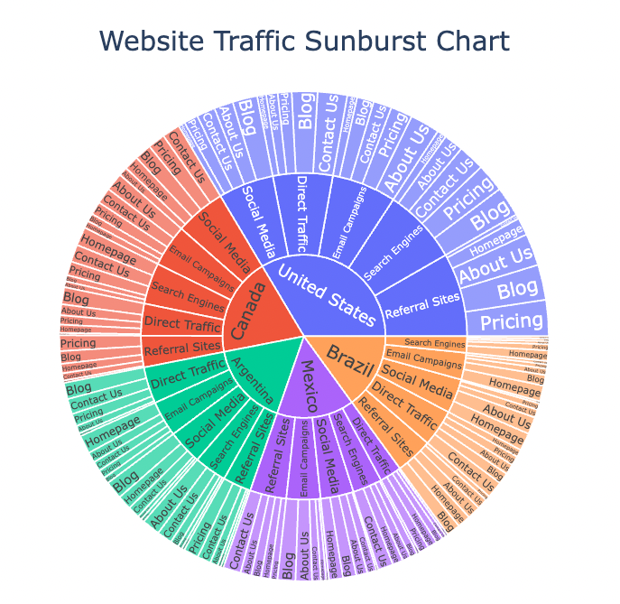

This image made me confident that I can show each of the teams total fantasy scoring in a sunburst plot, and that it won’t be too busy/cluttered. There are a ton of subgroups in the outer layers, so this graph inspired me to feel confident about building a sunburst plot of total fantasy points, then broken down by fantasy team, then broken down further by age group for each fantasy team.

### Plots

#### #1: Ridge plot (broad audience)

- One ridge for each fantasy team
- Data points are players fp_g
- Shade is the average age of each fantasy team
- Order from highest fp_g average to lowest fp_g average

#### #2: Sunburst plot (presentation)

- Break up each fantasy team into 3 groups: under 25, 25-29, and over 30
- Show the total fp_g for each fantasy team in the first layer, how their scores break down for each age group in second layer (0th layer is total fantasy points scored in the whole league)
- Color coordinate by team colors I have defined